# 한글 논문

이정훈, 권기민

2018-12-31 16:08:29

**Running headline**: 종족전쟁의 끝을 보고자 하십니까? 다음을 정독해 주세요.

**초록**: GUI 종족과 CLI 종족간의 전쟁은 끝이 보이지 않고 있다. 두 종족간의 전쟁은 윈도우의 출현으로 GUI 종족의 일방적인 승리로 끝날 것으로 보였지만, 클라우드 시대의 출현으로 다시 CLI 종족이 주도권을 잡아가고 있는 모양이 되었다. CLI 종족은 과거 소수였지만, 소프트웨어 카펜트리[Simperler and Wilson 2015]를 내세워서 GUI 종족을 흡수하면서 세력을 급격히 확장시키고 있다.

Simperler, A. and Wilson, G. 2015. Software carpentry get more done in less time. *CoRR* *abs/1506.02575*.

두 종족간의 전쟁은 어떻게 전개될까? 과연 과학 컴퓨팅[Wilson 2014]는 도움이 될까?

Wilson, D.A.A.B., Greg AND Aruliah. 2014. Best practices for scientific computing. *PLOS Biology* *12*, 1, 1–7.

## 종족전쟁 도해

[figure not shown]

## 수식

$$\text{생산성} = \frac{\text{CLI}^2}{\text{GUI}}$$

## 표

| Plot | sprich |
| --- | --- |
| 3294 | 31 |
| 3297 | 28 |
| 3299 | 26 |
| 3330 | 27 |

종족 평균값은 28.

수작업으로 표를 넣는 경우 2:

| Col A | Col B | Col C | Col D |
| --- | --- | --- | --- |
| row 1 | 190 | $112 \pm 2$ | $233 \pm 3$ |
| $\eta$ | 0.13 | 0.12 | 0.12 |
| $\eta^2$ | 0.14 | 0.13 | 0.50 |
| $\eta^3$ | 0.15 | 0.31 | 0.52 |

# R 그래프

그래프 참조를 하는 방법 2.

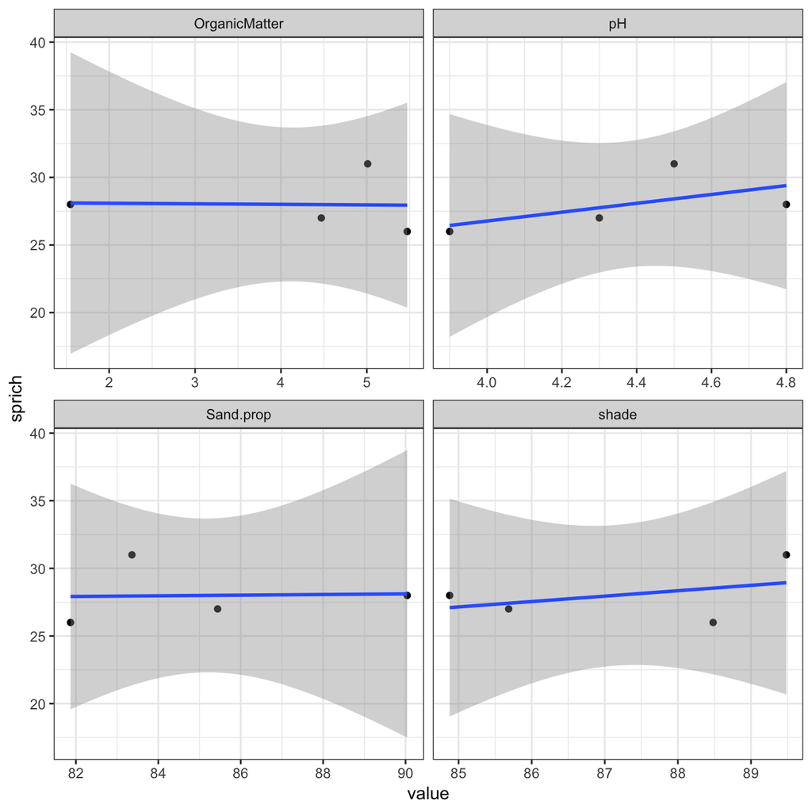

## 문제해결

GUI로 해결하기 힘든 아래와 같이 `pdf` 파일 생성시 생긴 문제는 구글 검색을 통해서 stackoverflow [Pandoc and foreign characters](https://stackoverflow.com/questions/18178084/pandoc-and-foreign-characters)에서 해법을 찾아 `--latex-engine=xelatex -V CJKmainfont=NanumGothic`와 같이 글꼴까지 반영시킨다.

```
! Package inputenc Error: Unicode character 내 (U+B0B4)
(inputenc)                not set up for use with LaTeX.
```

# R 코드

## 기술통계량

```
##       mpg            cyl            disp           hp           drat
##  Min.   :10.4   Min.   :4.00   Min.   : 71   Min.   : 52   Min.   :2.76
##  1st Qu.:15.4   1st Qu.:4.00   1st Qu.:121   1st Qu.: 96   1st Qu.:3.08
##  Median :19.2   Median :6.00   Median :196   Median :123   Median :3.69
##  Mean   :20.1   Mean   :6.19   Mean   :231   Mean   :147   Mean   :3.60
##  3rd Qu.:22.8   3rd Qu.:8.00   3rd Qu.:326   3rd Qu.:180   3rd Qu.:3.92
##  Max.   :33.9   Max.   :8.00   Max.   :472   Max.   :335   Max.   :4.93
```

## 회귀모형

```
## # A tibble: 2 x 5
##   term        estimate std.error statistic  p.value
##   <chr>          <dbl>     <dbl>     <dbl>    <dbl>
## 1 (Intercept)  29.6      1.23        24.1  3.58e-21
## 2 disp         -0.0412   0.00471     -8.75 9.38e-10
```

## 시각화

Figure 3: Mtcars 그래프

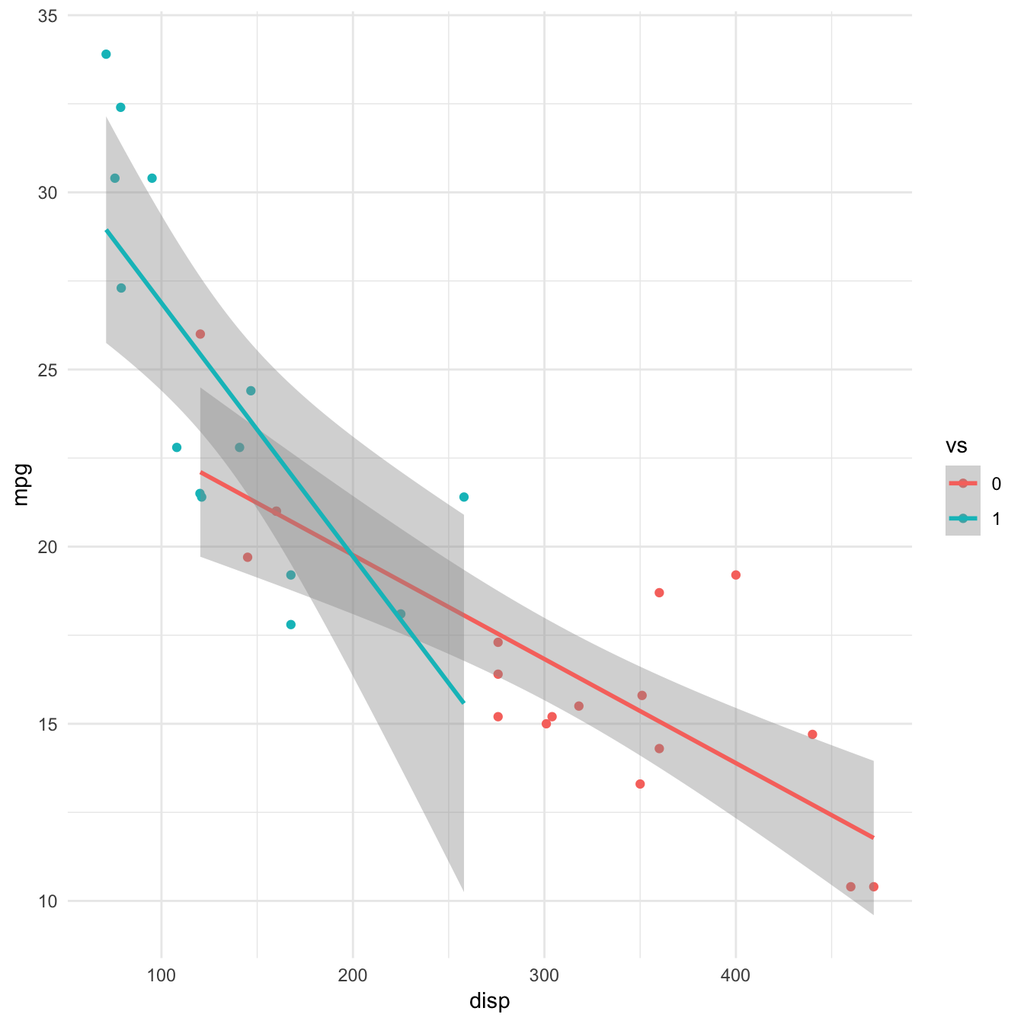